# Final-8

Mike Lehman

December 10, 2016

## Introduction

The goal of this assessment is to apply two different types of clustering algorithm to the widely used Iris data set to discover any patterns in the data that can be achieved through such unsupervised machine learning methods.

For this assessment we will be comparing K-Means clustering and hierarchical clustering. Clustering is simply a way of dividing data into groups of similar items without having been instructed as to what the groups should look like prior to grouping. Clustering works by plotting all data points into a two-dimensional feature space, then assigning random fixed positions and drawing boundaries which attempt to group all data points in homogenous groups.

The k-means algorithm uses simple ideas that are easy to understand, but is lacking in sophistication and is driven by a process of random selection that often may require several iterations to extract any meaningful information. The algorithm uses Euclidean distance to determine the spatial distance between two data points to determine which items should be considered homogenous and cluster boundaries drawn.

Hierarchical clustering involves creating clusters that have a predetermined ordering from top to bottom. There are two approaches to hierarchical clustering, divisive and agglomerative. In divisive clustering all observations are assigned to a single cluster, then the first cluster is partitioned into two clusters that are the least similar to one another. This proceeds recursively until there is one cluster for each observation. Agglomerative clustering assigns each observation to its own cluster, then computing the similarity between each of the clusters and joining the two most similar clusters. This step repeats until there is only a single cluster left.

The iris data set contains 150 observations of iris plants and certain characteristics of each plant. The plant types have three possible class labels which correspond to the species of each plant. Features included in the data set are petal and sepal lengths and widths. There are exactly 50 observations of each species type.

## K-Means Clustering

To begin our clustering analyses, we will first load the iris data into R from the UCI Machine Learning Repository.

```r
url = "http://archive.ics.uci.edu/ml/machine-learning-databases/iris/iris.data"
iris <- read.table(url, sep = ",", header = FALSE)
str(iris)
```

```
## 'data.frame':    150 obs. of  5 variables:
##  $ V1: num  5.1 4.9 4.7 4.6 5 5.4 4.6 5 4.4 4.9 ...
##  $ V2: num  3.5 3 3.2 3.1 3.6 3.9 3.4 3.4 2.9 3.1 ...
##  $ V3: num  1.4 1.4 1.3 1.5 1.4 1.7 1.4 1.5 1.4 1.5 ...
##  $ V4: num  0.2 0.2 0.2 0.2 0.2 0.4 0.3 0.2 0.2 0.1 ...
##  $ V5: Factor w/ 3 levels "Iris-setosa",..: 1 1 1 1 1 1 1 1 1 1 ...
```

We see there are the four numeric features regarding sepal length/width and petal length/width, as well as the species feature (V5) with the three factor levels for iris species.

K-Means clustering relies on distance calculations and this we must first scale any numeric features to prevent large outlier values from influencing the distance calculations:

```r
iris.z <- as.data.frame(lapply(iris[-5], scale))
iris.z$V5 <- iris$V5
str(iris.z)
```

```
## 'data.frame':    150 obs. of  5 variables:
##  $ V1: num  -0.898 -1.139 -1.381 -1.501 -1.018 ...
##  $ V2: num  1.029 -0.125 0.337 0.106 1.259 ...
##  $ V3: num  -1.34 -1.34 -1.39 -1.28 -1.34 ...
##  $ V4: num  -1.31 -1.31 -1.31 -1.31 -1.31 ...
##  $ V5: Factor w/ 3 levels "Iris-setosa",..: 1 1 1 1 1 1 1 1 1 1 ...
```

Here we’ve applied R’s scale function, which reassings all our numeric features using a z-score to instead have every value reflect its distance in standard deviation from the mean value in a new data frame to preserve the original data. We’ve also added the species feature into the new data frame for reference.

Now that our numeric features have been standardized, we can pass our new data frame to the kmeans() function, excepting the species factor vector since categorical data cannot be processed in a K-Means algorithm.

For the number of cluster centers to consider, we will use three since there are a total of three possible iris species:

```r
iris.kmeans <- kmeans(iris.z[-5], 3)
iris.kmeans$size
```

```
## [1]  35  15 100
```

```r
iris.kmeans$centers
```

```
##           V1         V2         V3         V4
## 1 -1.1909562  0.4026147 -1.3092658 -1.2674107
## 2 -0.5917402  1.8588805 -1.2801182 -1.2125012
## 3  0.5055957 -0.4197472  0.6502607  0.6254689
```

To further examine how the cluster assignments relate to the species label, we can assign the cluster assignments back to the original data set:

```r
iris.z$cluster <- iris.kmeans$cluster
iris.z[, c("V5", "cluster")]
```

```
##                  V5 cluster
## 1       Iris-setosa       1
## 2       Iris-setosa       1
## 3       Iris-setosa       1
## 4       Iris-setosa       1
## 5       Iris-setosa       2
## 6       Iris-setosa       2
## 7       Iris-setosa       1
## 8       Iris-setosa       1
## 9       Iris-setosa       1
## 10      Iris-setosa       1
## 11      Iris-setosa       2
## 12      Iris-setosa       1
## 13      Iris-setosa       1
## 14      Iris-setosa       1
```

[output cut: 136 more lines]

```r
table(iris.z$V5, iris.z$cluster)
```

```
##
##                    1  2  3
##   Iris-setosa     35 15  0
##   Iris-versicolor  0  0 50
##   Iris-virginica   0  0 50
```

```r
aggregate(data = iris.z, iris.z$V1 ~ cluster, mean)
```

```
##   cluster  iris.z$V1
## 1       1 -1.1909562
## 2       2 -0.5917402
## 3       3  0.5055957
```

```r
aggregate(data = iris.z, iris.z$V2 ~ cluster, mean)
```

```
##   cluster  iris.z$V2
## 1       1  0.4026147
## 2       2  1.8588805
## 3       3 -0.4197472
```

```r
aggregate(data = iris.z, iris.z$V3 ~ cluster, mean)
```

```
##   cluster  iris.z$V3
## 1       1 -1.3092658
## 2       2 -1.2801182
## 3       3  0.6502607
```

```r
aggregate(data = iris.z, iris.z$V4 ~ cluster, mean)
```

```
##   cluster  iris.z$V4
## 1       1 -1.2674107
## 2       2 -1.2125012
## 3       3  0.6254689
```

Here we’ve printed the mean values of each of the four numeric variables and aggergated them by cluster. Not suprisingly, cluster three’s mean feature values all appear to be quite close whereas clusters one and two appear to have a slightly larger distributions of values.

Next we will follow hierarchical clustering methods to see if the same results bear out using a different approach to clustering.

## Hierarchical Clustering

Hierarchical clustering is in some ways similar to decision tree models. Both are greedy algorithms which seek to optimize locally, which can result in suboptimal models, unlike K-Means which seeks to optimize globally by finding the optimal variance across clusters. Divisize clustering (a type of hierarchical clustering) is even conceptually similar to a decision tree in that all samples begin in one cluster with cluster splits being made iteratively until all samples are in unqiue clusters.

Agglomerative clustering proceeds in the opposite direction and assigns each samples to its own cluster, then iterates to determine which clusters should be joined and continues until each sample is assigned to a single cluster. Conceptually this is like an upside-down decision tree.

For our hierarchical clustering approach, each model we build will be based on agglomerative clustering.

To begin we will need to reassing the numeirc features within the iris data frame to a matrix. Specifically the data structure we need is a distance/dissimilarity matrix. This is simply a matrix that contains the distances between the elements (features) of a set:

```r
iris.matrix <- dist(as.matrix(iris.z[-5]))
```

Now that we have a distance matrix we can use that to build our hierarchical cluster model:

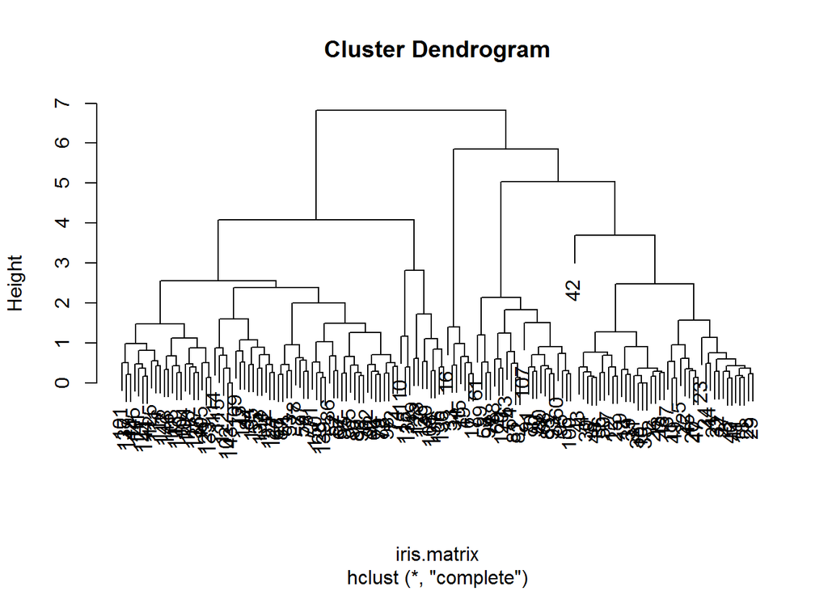

```r
iris.hc <- hclust(iris.matrix)
plot(iris.hc)
```

From the plot of the cluster model, we can see a dendrogram that shows each of the feature values terminating in their own cluster at the bottom of the tree. The y-axis is a measure of closeness of the individual data points and clusters. Each split shows a case where a new cluster was created based on an agglomerative approach as described above.

For modeling real world relationships it is not ideal to represent each feature in its own independent cluster. The ideal number of clusters is somewhere higher up in the dendrogram. Cutting a dendrogram refers to slicing a portion of the model out of the larger dendrogram based on a pre-determined value.

Similar to K-Means, the decision of when to cut a dendrogram is largely arbitrary and highly dependent on the context of the data. Since we are dealing with three possible classes of iris plant, we will cut the dendrogram at three clusters to get more useful results:

```r
iris.hc.cut <- cutree(iris.hc, 3)
iris.hc.cut
```

```
##   [1] 1 1 1 1 1 2 1 1 1 1 1 1 1 1 2 2 2 1 2 1 1 1 1 1 1 1 1 1 1 1 1 1 2 2 1
##  [36] 1 1 1 1 1 1 1 1 1 1 1 1 1 1 1 3 3 3 1 3 1 3 1 3 1 1 3 1 3 3 3 3 1 1 1
##  [71] 3 3 3 3 3 3 3 3 3 1 1 1 1 3 3 3 3 1 3 1 1 3 1 1 1 3 3 3 1 1 3 3 3 3 3
## [106] 3 1 3 3 3 3 3 3 3 3 3 3 3 3 1 3 3 3 3 3 3 3 3 3 3 3 3 3 3 3 3 3 3 3 3
## [141] 3 3 3 3 3 3 3 3 3 3
```

This produces a list of numeric values that correspond to cluster assignments. We can take this information and cross-reference it to the species values from our original data set to find how cluster assignments correspond to iris species:

```r
table(iris.hc.cut, iris$V5)
```

```
##
## iris.hc.cut Iris-setosa Iris-versicolor Iris-virginica
##           1          43              21              2
##           2           7               0              0
##           3           0              29             48
```

We can attempt to improve our model’s performance by specifying a method parameter when building the cluster. The method parameter refers to the linkage criteria, which determines the distance between sets of observations as a function of the pairwise distance between observations. Basically, how is the distance between data points calculated when considering new clusters.

The default method for hclust is complete linkage. In complete linkage, the distance between two data points is the largest distance between two points in opposite groups.

Average linkage takes the average distance over all points in opposite groups. The linkage method chosen determines how the distance between two clusters is defined.

We’ll now create a clsutering model using the average linkage method to see if we can produce more useful results:

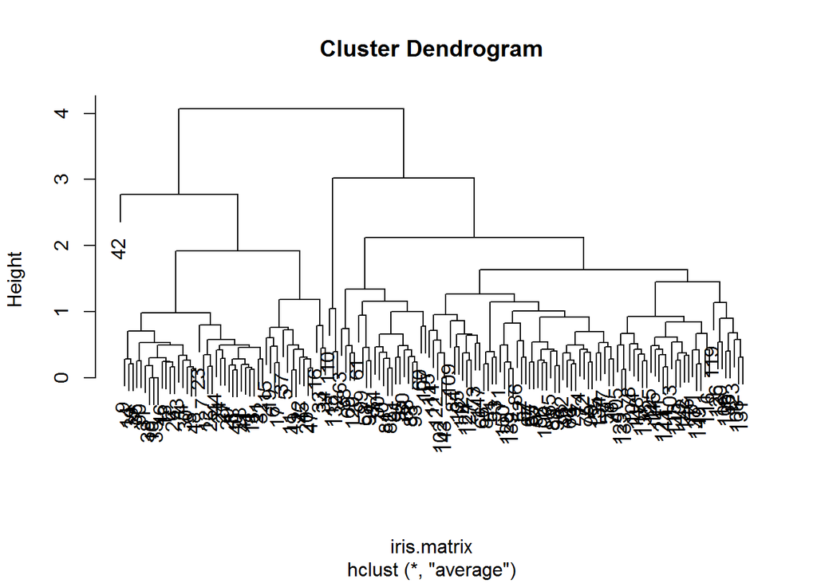

```r
iris.hc.2 <- hclust(iris.matrix, method = 'average')
plot(iris.hc.2)
```

Once again we will cut the dendrogram at three and compare those results to the species labels:

```r
iris.hc.cut.2 <- cutree(iris.hc.2, 3)
table(iris.hc.cut.2, iris$V5)
```

```
##
## iris.hc.cut.2 Iris-setosa Iris-versicolor Iris-virginica
##             1          50               0              0
##             2           0              50             47
##             3           0               0              3
```

## Conclusion

This does not necessarily mean that the model is bad, it may be the case the Iris-versicolor and Iris-virginica plants are much tougher to cluster homogenously.

In general hierarchical clustering works better when the data has an inherent hierarchical structure, and you are seeking to rediscover that hierarchy. The findings from our hierarchical cluster model would seem to imply that iris plant feature have an inherent hierarchical structure, meaning samples can be separated into homogenous groups

R Source